# Project: No-Show Appointments

- Introduction
- Data Wrangling
- Exploratory Data Analysis
- Conclusions

## Introduction

For this project, I analysed the No_Show Appointment dataset which consists of information of around 100 thousand medical appointments collected from Brazil. The dataset is focused on answering the question of whether or not patients show up for their appointment and it contains 14 columns.

#### Dataset Columns and Description

- PatientId: Identification of a patient.
- AppointmentID: Identification of each appointment.
- Gender: Male or Female.
- ScheduledDay: The day patient set up their appointment.
- AppointmentDay: The actual day of appointment.
- Age: How old the patient is.
- Neighbourhood: Location of the hospital.
- Scholarship: Indicates whether or not the patient is enrolled in Brasilian welfare program Bolsa Família (True(1) or False(0)).
- Hipertension: Indicates whether or not the patient has hypertension (True(1) or False(0)).
- Diabetes: Indicates whether or not the patient has diabetes (True(1) or False(0)).
- Alcoholism: Indicates whether or not the patient has alcoholism (True(1) or False(0)).
- Handcap: Indicates whether or not the patient is handicapped (on a scale of 0 to 4).
- SMS_received: Indicates whether or not 1 or more messages was sent to the patient (True(1) or False(0)).
- No-show: It says ‘No’ if the patient showed up to their appointment, and ‘Yes’ if they did not show up. #### Questions
1. What are the characteristics of people who missed their appointment?
2. Does sending messages to patients increase the chances of them showing up?
3. Do older people show up more?
4. Which gender schedules appointments more?
5. Which gender missed appointments more?
6. Are older people more prone to the diseases and which are they most prone to?
7. Which disease group missed appointments the most?
8. Which day did most people have their appointments scheduled?
9. What day do people miss appointments more?

```python
#import necessary packages
import pandas as pd
import numpy as np
import matplotlib.pyplot as plt
import seaborn as sns

%matplotlib inline
sns.set_style('darkgrid')
```

## Data Wrangling

### General Properties

```python
# load dataset and print out first few lines
df = pd.read_csv('noshowappointments-kagglev2-may-2016.csv')
df.head()
```

|  | PatientId | AppointmentID | Gender | ScheduledDay | AppointmentDay | Age | Neighbourhood | Scholarship | Hipertension | Diabetes | Alcoholism | Handcap | SMS_received | No-show |
| --- | --- | --- | --- | --- | --- | --- | --- | --- | --- | --- | --- | --- | --- | --- |
| 0 | 2.987250e+13 | 5642903 | F | 2016-04-29T18:38:08Z | 2016-04-29T00:00:00Z | 62 | JARDIM DA PENHA | 0 | 1 | 0 | 0 | 0 | 0 | No |
| 1 | 5.589978e+14 | 5642503 | M | 2016-04-29T16:08:27Z | 2016-04-29T00:00:00Z | 56 | JARDIM DA PENHA | 0 | 0 | 0 | 0 | 0 | 0 | No |
| 2 | 4.262962e+12 | 5642549 | F | 2016-04-29T16:19:04Z | 2016-04-29T00:00:00Z | 62 | MATA DA PRAIA | 0 | 0 | 0 | 0 | 0 | 0 | No |
| 3 | 8.679512e+11 | 5642828 | F | 2016-04-29T17:29:31Z | 2016-04-29T00:00:00Z | 8 | PONTAL DE CAMBURI | 0 | 0 | 0 | 0 | 0 | 0 | No |
| 4 | 8.841186e+12 | 5642494 | F | 2016-04-29T16:07:23Z | 2016-04-29T00:00:00Z | 56 | JARDIM DA PENHA | 0 | 1 | 1 | 0 | 0 | 0 | No |

```python
# get the number of rows and columns
df.shape
```

```
(110527, 14)
```

The dataset has 110527 rows and 14 columns

```python
# get datatype of each column
df.dtypes
```

```
PatientId         float64
AppointmentID       int64
Gender             object
ScheduledDay       object
AppointmentDay     object
Age                 int64
Neighbourhood      object
Scholarship         int64
Hipertension        int64
Diabetes            int64
Alcoholism          int64
Handcap             int64
SMS_received        int64
No-show            object
dtype: object
```

```python
# get the concise summary of dataframe
df.info()
```

```
<class 'pandas.core.frame.DataFrame'>
RangeIndex: 110527 entries, 0 to 110526
Data columns (total 14 columns):
 #   Column          Non-Null Count   Dtype
---  ------          --------------   -----
 0   PatientId       110527 non-null  float64
 1   AppointmentID   110527 non-null  int64
 2   Gender          110527 non-null  object
 3   ScheduledDay    110527 non-null  object
 4   AppointmentDay  110527 non-null  object
 5   Age             110527 non-null  int64
 6   Neighbourhood   110527 non-null  object
 7   Scholarship     110527 non-null  int64
 8   Hipertension    110527 non-null  int64
 9   Diabetes        110527 non-null  int64
 10  Alcoholism      110527 non-null  int64
 11  Handcap         110527 non-null  int64
 12  SMS_received    110527 non-null  int64
 13  No-show         110527 non-null  object
dtypes: float64(1), int64(8), object(5)
memory usage: 11.8+ MB
```

```python
# view missing value count for each feature
df.isnull().sum()
```

```
PatientId         0
AppointmentID     0
Gender            0
ScheduledDay      0
AppointmentDay    0
Age               0
Neighbourhood     0
Scholarship       0
Hipertension      0
Diabetes          0
Alcoholism        0
Handcap           0
SMS_received      0
No-show           0
dtype: int64
```

There are no missing values in the dataset

```python
# view the number of duplicated rows
df.duplicated().sum()
```

```
0
```

There are no duplicated rows

```python
# get descriptive statistics of dataset
df.describe()
```

|  | PatientId | AppointmentID | Age | Scholarship | Hipertension | Diabetes | Alcoholism | Handcap | SMS_received |
| --- | --- | --- | --- | --- | --- | --- | --- | --- | --- |
| count | 1.105270e+05 | 1.105270e+05 | 110527.000000 | 110527.000000 | 110527.000000 | 110527.000000 | 110527.000000 | 110527.000000 | 110527.000000 |
| mean | 1.474963e+14 | 5.675305e+06 | 37.088874 | 0.098266 | 0.197246 | 0.071865 | 0.030400 | 0.022248 | 0.321026 |
| std | 2.560949e+14 | 7.129575e+04 | 23.110205 | 0.297675 | 0.397921 | 0.258265 | 0.171686 | 0.161543 | 0.466873 |
| min | 3.921784e+04 | 5.030230e+06 | -1.000000 | 0.000000 | 0.000000 | 0.000000 | 0.000000 | 0.000000 | 0.000000 |
| 25% | 4.172614e+12 | 5.640286e+06 | 18.000000 | 0.000000 | 0.000000 | 0.000000 | 0.000000 | 0.000000 | 0.000000 |
| 50% | 3.173184e+13 | 5.680573e+06 | 37.000000 | 0.000000 | 0.000000 | 0.000000 | 0.000000 | 0.000000 | 0.000000 |
| 75% | 9.439172e+13 | 5.725524e+06 | 55.000000 | 0.000000 | 0.000000 | 0.000000 | 0.000000 | 0.000000 | 1.000000 |
| max | 9.999816e+14 | 5.790484e+06 | 115.000000 | 1.000000 | 1.000000 | 1.000000 | 1.000000 | 4.000000 | 1.000000 |

From above, the minimum age is an invalid number

```python
# get the rows that have -1 as the age
df[df['Age'] == -1]
```

|  | PatientId | AppointmentID | Gender | ScheduledDay | AppointmentDay | Age | Neighbourhood | Scholarship | Hipertension | Diabetes | Alcoholism | Handcap | SMS_received | No-show |
| --- | --- | --- | --- | --- | --- | --- | --- | --- | --- | --- | --- | --- | --- | --- |
| 99832 | 4.659432e+14 | 5775010 | F | 2016-06-06T08:58:13Z | 2016-06-06T00:00:00Z | -1 | ROMÃO | 0 | 0 | 0 | 0 | 0 | 0 | No |

```python
# get the number of distinct elements in each column
df.nunique()
```

```
PatientId          62299
AppointmentID     110527
Gender                 2
ScheduledDay      103549
AppointmentDay        27
Age                  104
Neighbourhood         81
Scholarship            2
Hipertension           2
Diabetes               2
Alcoholism             2
Handcap                5
SMS_received           2
No-show                2
dtype: int64
```

```python
# get unique values of the columns and their respective counts
unique_columns = ['Gender', 'AppointmentDay', 'Age', 'Neighbourhood', 'Scholarship',
                  'Hipertension','Diabetes', 'Alcoholism', 'Handcap', 'SMS_received', 'No-show']
for col in unique_columns:
    print(df[col].value_counts())
    print('-'*50)
```

```
F    71840
M    38687
Name: Gender, dtype: int64
--------------------------------------------------
2016-06-06T00:00:00Z    4692
2016-05-16T00:00:00Z    4613
2016-05-09T00:00:00Z    4520
2016-05-30T00:00:00Z    4514
2016-06-08T00:00:00Z    4479
2016-05-11T00:00:00Z    4474
2016-06-01T00:00:00Z    4464
2016-06-07T00:00:00Z    4416
2016-05-12T00:00:00Z    4394
2016-05-02T00:00:00Z    4376
2016-05-18T00:00:00Z    4373
2016-05-17T00:00:00Z    4372
2016-06-02T00:00:00Z    4310
2016-05-10T00:00:00Z    4308
2016-05-31T00:00:00Z    4279
2016-05-05T00:00:00Z    4273
2016-05-19T00:00:00Z    4270
2016-05-03T00:00:00Z    4256
2016-05-04T00:00:00Z    4168
2016-06-03T00:00:00Z    4090
2016-05-24T00:00:00Z    4009
2016-05-13T00:00:00Z    3987
2016-05-25T00:00:00Z    3909
2016-05-06T00:00:00Z    3879
2016-05-20T00:00:00Z    3828
2016-04-29T00:00:00Z    3235
2016-05-14T00:00:00Z      39
Name: AppointmentDay, dtype: int64
--------------------------------------------------
 0      3539
 1      2273
 52     1746
 49     1652
 53     1651
        ...
 115       5
```

[output cut: 35 more lines]

```
0    108286
1      2042
2       183
3        13
4         3
Name: Handcap, dtype: int64
--------------------------------------------------
0    75045
1    35482
Name: SMS_received, dtype: int64
--------------------------------------------------
No     88208
Yes    22319
Name: No-show, dtype: int64
--------------------------------------------------
```

From the assessment, the problems with the dataset include:

- Extraneous columns (PatientId, AppointmentID, ScheduledDay)
- Misspelled and inconsistent column headers (Handcap, Hipertension, No-show)
- Column with incorrect datatype (AppointmentDay)
- Invalid data (Age = -1)

### Data Cleaning

- Drop extraneous columns (PatientId, AppointmentID, ScheduledDay)
- Select misspelled and inconsistent column headers (Handcap, Hipertension, No-show) and replace them with proper spelling (Handicap, Hypertension, No_show)
- Select column (AppointmentDay) with incorrect datatype (string), convert to datetime, and extract day of the week
- Drop invalid data (Age = -1)

#### Drop Extraneous Columns

```python
# drop columns
df = df.drop(['PatientId', 'AppointmentID', 'ScheduledDay'], axis=1)

# confirm drop
df.head(1)
```

|  | Gender | AppointmentDay | Age | Neighbourhood | Scholarship | Hipertension | Diabetes | Alcoholism | Handcap | SMS_received | No-show |
| --- | --- | --- | --- | --- | --- | --- | --- | --- | --- | --- | --- |
| 0 | F | 2016-04-29T00:00:00Z | 62 | JARDIM DA PENHA | 0 | 1 | 0 | 0 | 0 | 0 | No |

#### Rename Columns

```python
# rename columns
df = df.rename(columns={'No-show':'No_show', 'Hipertension':'Hypertension', 'Handcap':'Handicap'})

# confirm change
df.head(1)
```

|  | Gender | AppointmentDay | Age | Neighbourhood | Scholarship | Hypertension | Diabetes | Alcoholism | Handicap | SMS_received | No_show |
| --- | --- | --- | --- | --- | --- | --- | --- | --- | --- | --- | --- |
| 0 | F | 2016-04-29T00:00:00Z | 62 | JARDIM DA PENHA | 0 | 1 | 0 | 0 | 0 | 0 | No |

#### Change AppointmentDay Format

```python
# change AppointmentDay datatype from string to datetime
df['AppointmentDay'] = pd.to_datetime(df['AppointmentDay'])

# confirm change
df['AppointmentDay'].dtype
```

```
datetime64[ns, UTC]
```

```python
# change AppointmentDay from date to day of the week
df['AppointmentDay'] = df['AppointmentDay'].dt.day_name()

# confirm change
df['AppointmentDay'].value_counts()
```

```
Wednesday    25867
Tuesday      25640
Monday       22715
Friday       19019
Thursday     17247
Saturday        39
Name: AppointmentDay, dtype: int64
```

#### Drop Row with Negative Age

```python
# drop row where age is negative
df = df.drop(df.index[df['Age'] < 0], axis=0)

#confirm drop
df[df['Age'] < 0]
```

|  | Gender | AppointmentDay | Age | Neighbourhood | Scholarship | Hypertension | Diabetes | Alcoholism | Handicap | SMS_received | No_show |
| --- | --- | --- | --- | --- | --- | --- | --- | --- | --- | --- | --- |

## Exploratory Data Analysis

### Histogram of Various Features

To understand the distribution of the columns in the dataset

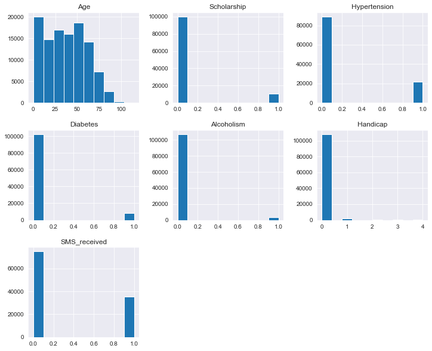

```python
df.hist(figsize=(12,10));
```

- From the histogram plots it is easy to tell that the most of the columns in the dataset are categorical, with Age being the only numerical column.
- The Age column appears to be skewed to the right with most people falling between the age range of 0 to 60, and children between the ages of 0 and 12 taking a population of around 20,000.
- Among the categorical columns, we can deduce that only about 10,000 people have scholarships, close to 40,000 people received at least one message, and the disease most people are associated with between Hyprtension, Diabtes, Alcoholism and Handicap is Hypertension

### What are the characteristics of people who missed their appointment?

```python
# get count of people who missed and didn't miss their appointment
df['No_show'].value_counts()
```

```
No     88207
Yes    22319
Name: No_show, dtype: int64
```

```python
# function to set the labels for the x-axis, y-axis and the title of the plots
def label(x_label,y_label,title):
    '''Sets the labels for the x-axis, y-axis and the title of the plots'''
    plt.title(title)
    plt.xlabel(x_label)
    plt.ylabel(y_label)
    plt.show()
```

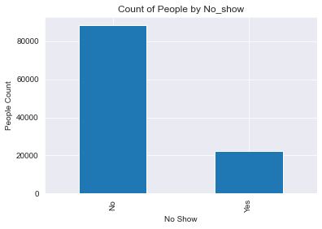

```python
# bar chart showing count of people who missed and didn't miss their appointment
df['No_show'].value_counts().plot(kind='bar')
label('No Show','People Count','Count of People by No_show')
```

```python
# select people who showed up for appointment
df_show = df.query('No_show == "No"')
df_show.shape
```

```
(88207, 11)
```

```python
# select people who didn't show up for appointment
df_no_show = df.query('No_show == "Yes"')
df_no_show.shape
```

```
(22319, 11)
```

```python
# get percentage of those who missed their appointment
perc_no_show = df_no_show.shape[0]/df.shape[0]
perc_no_show
```

```
0.20193438647919945
```

```python
#characteristics of people who missed their appointment
df_no_show.describe()
```

|  | Age | Scholarship | Hypertension | Diabetes | Alcoholism | Handicap | SMS_received |
| --- | --- | --- | --- | --- | --- | --- | --- |
| count | 22319.000000 | 22319.000000 | 22319.000000 | 22319.000000 | 22319.000000 | 22319.000000 | 22319.000000 |
| mean | 34.317667 | 0.115507 | 0.169004 | 0.064071 | 0.030333 | 0.020297 | 0.438371 |
| std | 21.965941 | 0.319640 | 0.374764 | 0.244885 | 0.171505 | 0.156670 | 0.496198 |
| min | 0.000000 | 0.000000 | 0.000000 | 0.000000 | 0.000000 | 0.000000 | 0.000000 |
| 25% | 16.000000 | 0.000000 | 0.000000 | 0.000000 | 0.000000 | 0.000000 | 0.000000 |
| 50% | 33.000000 | 0.000000 | 0.000000 | 0.000000 | 0.000000 | 0.000000 | 0.000000 |
| 75% | 51.000000 | 0.000000 | 0.000000 | 0.000000 | 0.000000 | 0.000000 | 1.000000 |
| max | 115.000000 | 1.000000 | 1.000000 | 1.000000 | 1.000000 | 4.000000 | 1.000000 |

```python
# get characteristics of the object columns
df_no_show.describe(exclude=[np.number])
```

|  | Gender | AppointmentDay | Neighbourhood | No_show |
| --- | --- | --- | --- | --- |
| count | 22319 | 22319 | 22319 | 22319 |
| unique | 2 | 6 | 80 | 1 |
| top | F | Tuesday | JARDIM CAMBURI | Yes |
| freq | 14594 | 5152 | 1465 | 22319 |

### Does sending messages to patients increase the chances of them showing up?

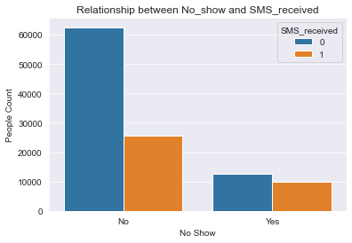

```python
# countplot showing the relationship between No_show and SMS_received
sns.countplot(data=df, x='No_show', hue='SMS_received')
label('No Show', 'People Count','Relationship between No_show and SMS_received')
```

```python
# get percentage
pd.crosstab(df['No_show'], df['SMS_received'], normalize='index')
```

| SMS_received No_show | 0 | 1 |
| --- | --- | --- |
| No | 0.708663 | 0.291337 |
| Yes | 0.561629 | 0.438371 |

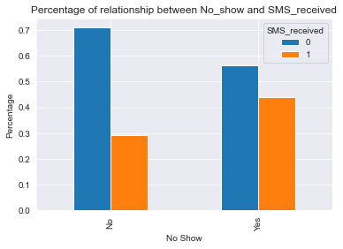

```python
# bar chart of the percentages
pd.crosstab(df['No_show'], df['SMS_received'], normalize='index').plot.bar()
label('No Show', 'Percentage','Percentage of relationship between No_show and SMS_received')
```

No, sending messages to patients does not increase the chances of them showing up for their appointment. From the analysis, 43.8 percent of the people that missed their appointment received messages. This is higher than the 29.1 percent of people that showed up and received messages as shown in the bar chart above.

### Do older people show up more?

```python
# get the average age of people that showed up and didn't
df.groupby('No_show').mean()['Age']
```

```
No_show
No     37.790504
Yes    34.317667
Name: Age, dtype: float64
```

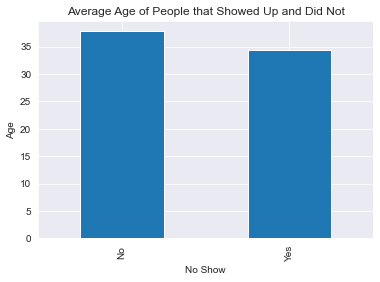

```python
# bar chart showing the average age of people that showed up and didn't
df.groupby('No_show').mean()['Age'].plot(kind='bar')
label('No Show','Age','Average Age of People that Showed Up and Did Not')
```

The average age of people who missed their appointment was 34.3, while that of those who showed up was 37.8. Hence, from the analysis, older people show up more to their appointments.

### Which gender schedules appointment more?

```python
# get number of males and females that schedueled appointment
df['Gender'].value_counts()
```

```
F    71839
M    38687
Name: Gender, dtype: int64
```

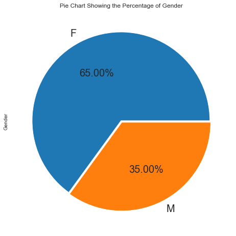

```python
# bar chart showing number of males and females that schedueled appointment
plt.figure(figsize=(8,8))
df['Gender'].value_counts().plot(kind='pie', autopct='%1.2f%%', textprops={'fontsize':20},
                                 explode=(0.01,0.01), title='Pie Chart Showing the Percentage of Gender');
```

From this dataset, 65% of people who scheduled appointment were females. Hence, it is safe to say that females generally schedule appointments more than males.

### Which gender missed appointments more?

```python
# get number of people that missed their appointments by gender
df_no_show['Gender'].value_counts()
```

```
F    14594
M     7725
Name: Gender, dtype: int64
```

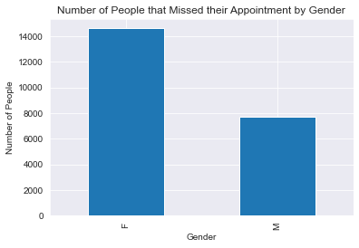

```python
# bar chart showing number of people that missed their appointments by gender
df_no_show['Gender'].value_counts().plot(kind='bar')
label('Gender','Number of People','Number of People that Missed their Appointment by Gender')
```

Since females are generally more than males, it will be inaccurate to use the number of people by gender that missed their appointment to conclude the analysis. Hence, it's important to get the proportion of males and females that didn't show up.

```python
# number of males and females that missed their appointment
no_show_f = df_no_show.query('Gender == "F"').shape[0]
no_show_m = df_no_show.query('Gender == "M"').shape[0]

no_show_f, no_show_m
```

```
(14594, 7725)
```

```python
# total number of males and females
total_f = df.query('Gender == "F"').shape[0]
total_m = df.query('Gender == "M"').shape[0]

total_f, total_m
```

```
(71839, 38687)
```

```python
# get proportion by dividing the no show gender with total gender

prop_no_show_f =  no_show_f/total_f
prop_no_show_m =  no_show_m/total_m
prop_no_show_f, prop_no_show_m
```

```
(0.20314870752655242, 0.19967947889471915)
```

```python
# get pecentage difference between the proportion of males and females that missed appointment
perc_diff = (prop_no_show_f - prop_no_show_m)*100
perc_diff
```

```
0.3469228631833271
```

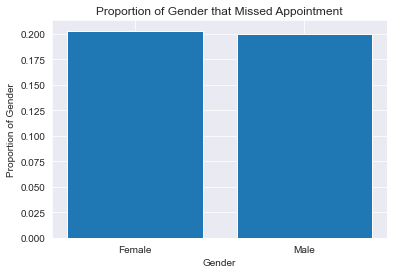

```python
heights = [prop_no_show_f, prop_no_show_m]
labels = ['Female', 'Male']
plt.bar([1,2], heights, tick_label=labels)
label('Gender','Proportion of Gender','Proportion of Gender that Missed Appointment')
```

Females missed their appointments more, but only by 0.34 percent.

### Are older people more prone to the diseases and which are they most prone to?

```python
# get average age of people with and without a disease
diseases = ['Hypertension', 'Diabetes', 'Alcoholism', 'Handicap']
for disease in diseases:
    print(df.groupby(disease).mean()['Age'])
    print('-'*30)
```

```
Hypertension
0    31.308943
1    60.613596
Name: Age, dtype: float64
------------------------------
Diabetes
0    35.208962
1    61.372529
Name: Age, dtype: float64
------------------------------
Alcoholism
0    36.697161
1    49.593750
Name: Age, dtype: float64
------------------------------
Handicap
0    36.810814
1    50.855044
2    47.775956
3    48.615385
4    14.333333
Name: Age, dtype: float64
------------------------------
```

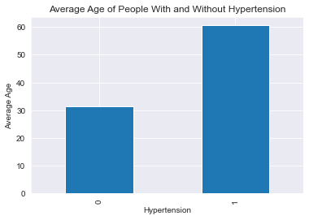

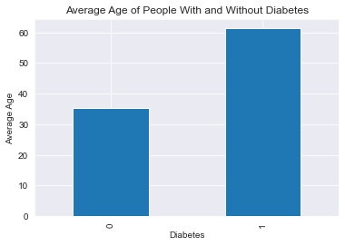

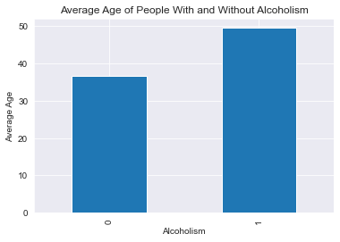

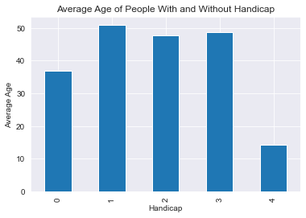

```python
# bar chart showing average age of people with and without a disease
diseases = ['Hypertension', 'Diabetes', 'Alcoholism', 'Handicap']
for disease in diseases:
    df.groupby(disease).mean()['Age'].plot(kind='bar')
    label(f'{disease}','Average Age',f'Average Age of People With and Without {disease}')
```

Older people are generally more prone to diseases, and from the analysis, older people are most prone to Diabetes

### Which disease group missed appointments the most?

```python
# get number of people who missed and did not miss appointments by disease
diseases = ['Hypertension', 'Diabetes', 'Alcoholism', 'Handicap']
for disease in diseases:
    print(df.query(f'{disease} != {0}')['No_show'].value_counts())
    print(f'{disease}')
    print('-'*30)
```

```
No     18029
Yes     3772
Name: No_show, dtype: int64
Hypertension
------------------------------
No     6513
Yes    1430
Name: No_show, dtype: int64
Diabetes
------------------------------
No     2683
Yes     677
Name: No_show, dtype: int64
Alcoholism
------------------------------
No     1834
Yes     407
Name: No_show, dtype: int64
Handicap
------------------------------
```

```python
# get the percentage of those who missed their appointments by disease
diseases = ['Hypertension', 'Diabetes', 'Alcoholism', 'Handicap']
perc = []
for disease in diseases:
    dis_no_show = df.query(f'{disease} != {0}')['No_show']
    perc_no_show = (dis_no_show == 'Yes').sum()/dis_no_show.count()
    perc.append(perc_no_show)
perc
```

```
[0.17301958625751113,
 0.18003273322422259,
 0.20148809523809524,
 0.18161535029004908]
```

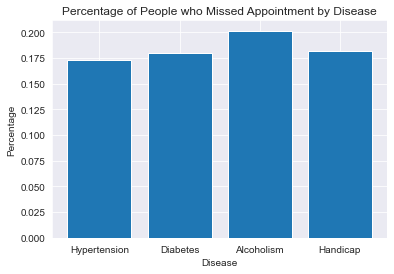

```python
# bar chart showing percentage of those who missed their appointments by disease
plt.bar([1,2,3,4], perc, tick_label=diseases)
label('Disease','Percentage',f'Percentage of People who Missed Appointment by Disease')
```

From the chart, it can be seen that those dealing with alcoholism missed their appointments more than those dealing with other diseases

### Which day did most people have their appointments scheduled?

```python
# get value counts of appointment day
df['AppointmentDay'].value_counts()
```

```
Wednesday    25867
Tuesday      25640
Monday       22714
Friday       19019
Thursday     17247
Saturday        39
Name: AppointmentDay, dtype: int64
```

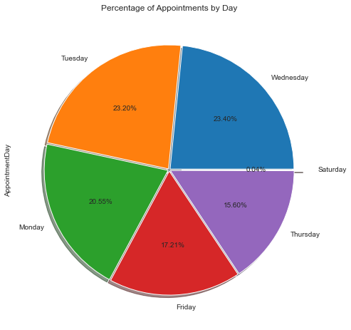

```python
# pie chart showing percentage of appointments by day
plt.figure(figsize=(8,8))
df['AppointmentDay'].value_counts().plot(kind='pie', autopct='%1.2f%%', shadow=True, explode=(0.01,0.01,0.01,0.01,0.01,0.1,))
plt.title('Percentage of Appointments by Day');
```

Most people (23.4%) had their appointments scheduled on Wednesday, while only 0.04% of people had their appointments on Saturday and none on Sunday

### What day do people miss appointments more?

```python
# get value counts of those who missed their appointments by day
df_no_show['AppointmentDay'].value_counts()
```

```
Tuesday      5152
Wednesday    5093
Monday       4690
Friday       4037
Thursday     3338
Saturday        9
Name: AppointmentDay, dtype: int64
```

```python
# percentage of those who missed appointments by days of the week
days = ['Monday','Tuesday','Wednesday','Thursday', 'Friday','Saturday']
perc_days = []
for day in days:
    day_no_show = df_no_show.query(f"AppointmentDay == '{day}'").shape[0]
    total_day = df.query(f"AppointmentDay == '{day}'").shape[0]
    perc_day = day_no_show/total_day
    perc_days.append(perc_day)
    print(day)
    print(f'Percent: {perc_day},\nNumber of people who missed appointment: {day_no_show},\nTotal number of people: {total_day}')
    print('-'*50)
perc_days
```

```
Monday
Percent: 0.20648058466144228,
Number of people who missed appointment: 4690,
Total number of people: 22714
--------------------------------------------------
Tuesday
Percent: 0.20093603744149766,
Number of people who missed appointment: 5152,
Total number of people: 25640
--------------------------------------------------
Wednesday
Percent: 0.19689179263153825,
Number of people who missed appointment: 5093,
Total number of people: 25867
--------------------------------------------------
Thursday
Percent: 0.1935409056647533,
Number of people who missed appointment: 3338,
Total number of people: 17247
--------------------------------------------------
Friday
Percent: 0.21226142278773857,
Number of people who missed appointment: 4037,
Total number of people: 19019
--------------------------------------------------
Saturday
Percent: 0.23076923076923078,
Number of people who missed appointment: 9,
Total number of people: 39
--------------------------------------------------
```

```
[0.20648058466144228,
 0.20093603744149766,
 0.19689179263153825,
 0.1935409056647533,
 0.21226142278773857,
 0.23076923076923078]
```

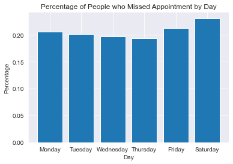

```python
# bar chart showing percentage of those who missed appointments by day
plt.bar(np.arange(len(perc_days)), perc_days, tick_label=days)
label('Day','Percentage','Percentage of People who Missed Appointment by Day')
```

From the dataset, 23 percent of those that had appointment on Saturdays didn't show up. Saturday had the highest rate of people who missed their appointment.

## Conclusions

### Findings

- Females schedule appointments more than males
- Sending messages did not increase the rate at which patients show up for their appointment
- Older people showed up more for appointment
- Gender has no relationship with the rate at which patients miss their appointment
- Older people are more prone to diseases
- Diabetes is the most associated with older people
- People rarely had appointments on Saturday
- Despite Saturday having the least appointment rate, it also had the least show up rate

### Limitations

- The AppointmentDay column only had date and didn't have the time of day in hours, minutes and seconds
- Inferential statistics wasn't used in this analysis, so statistical conclusions can't be implied.